# Tugas Kuliah 2-Penanganan Autokorelasi

Nama : Aliyah Nadhratunnaim NIM : G1401231087

Data yang digunakan adalah data Indeks Pembangunan Manusia Provinsi Bengkulu tahun 2010-2024.

# Import Data

```r
library(readxl)
df <- read_excel("~/Aliyah/SEMESTER 5/MPDW/IPM BENGKULU.xlsx")
df
```

```
## # A tibble: 15 × 2
##    Tahun   IPM
##    <dbl> <dbl>
##  1  2010  65.4
##  2  2011  66.0
##  3  2012  66.6
##  4  2013  67.5
##  5  2014  68.1
##  6  2015  68.6
##  7  2016  69.3
##  8  2017  70.0
##  9  2018  70.6
## 10  2019  71.2
## 11  2020  71.4
## 12  2021  71.6
## 13  2022  72.2
## 14  2023  72.8
## 15  2024  73.4
```

# Model Regresi

```r
model <- lm(formula = IPM ~ Tahun, data = df)
summary(model)
```

```
##
## Call:
## lm(formula = IPM ~ Tahun, data = df)
##
## Residuals:
##      Min       1Q   Median       3Q      Max
## -0.33600 -0.25086  0.06829  0.18843  0.44286
##
## Coefficients:
##               Estimate Std. Error t value Pr(>|t|)
## (Intercept) -1.069e+03  3.483e+01  -30.69 1.62e-13 ***
## Tahun        5.646e-01  1.727e-02   32.69 7.21e-14 ***
## ---
## Signif. codes:  0 '***' 0.001 '**' 0.01 '*' 0.05 '.' 0.1 ' ' 1
##
## Residual standard error: 0.289 on 13 degrees of freedom
## Multiple R-squared:  0.988,  Adjusted R-squared:  0.9871
## F-statistic:  1069 on 1 and 13 DF,  p-value: 7.206e-14
```

# Pengujian Autokorelasi

```r
library(lmtest)
dwtest(model)
```

```
##
##  Durbin-Watson test
##
## data:  model
## DW = 0.38584, p-value = 1.262e-06
## alternative hypothesis: true autocorrelation is greater than 0
```

Hasil uji Durbin Watson menunjukkan bahwa model regresi tersebut melanggar asumsi autokorelasi. Hal ini ditunjukkan dengan nilai p-value berada di bawah 0,05.

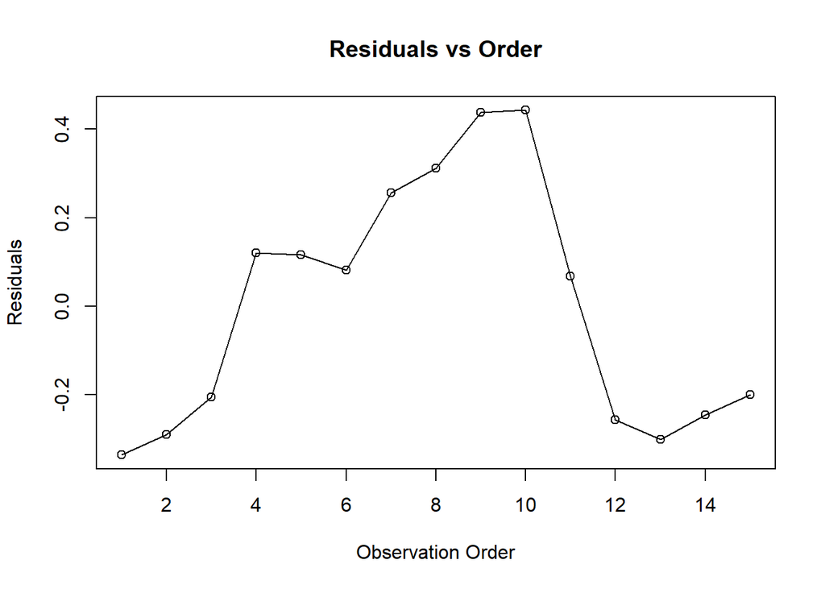

```r
# Sisaan
res <- residuals(model)

# Plot residual vs order observasi
plot(res, type = "o", main = "Residuals vs Order",
     ylab = "Residuals", xlab = "Observation Order")
```

Plot sisaan vs order juga menunjukkan pola sehingga terdapat indikasi adanya autokorelasi pada model regresi.

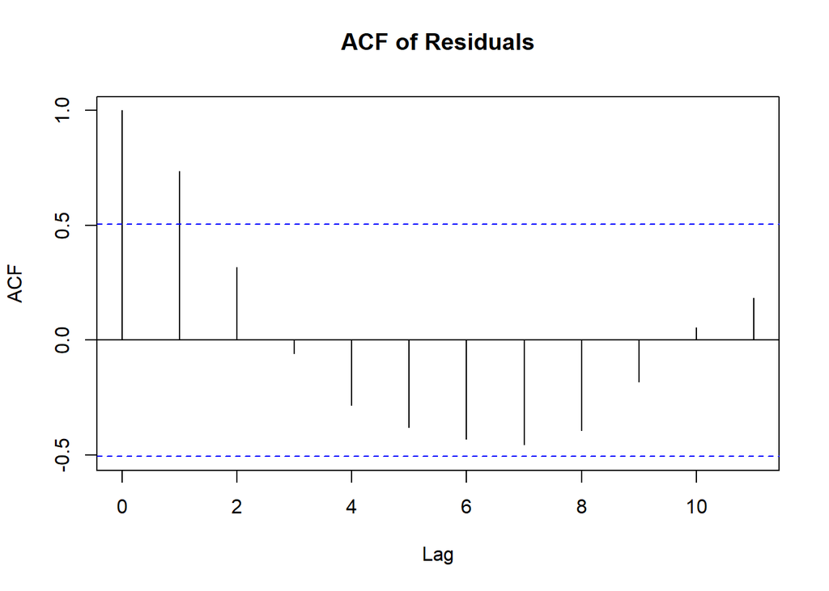

```r
# Plot ACF
acf(res, main = "ACF of Residuals")
```

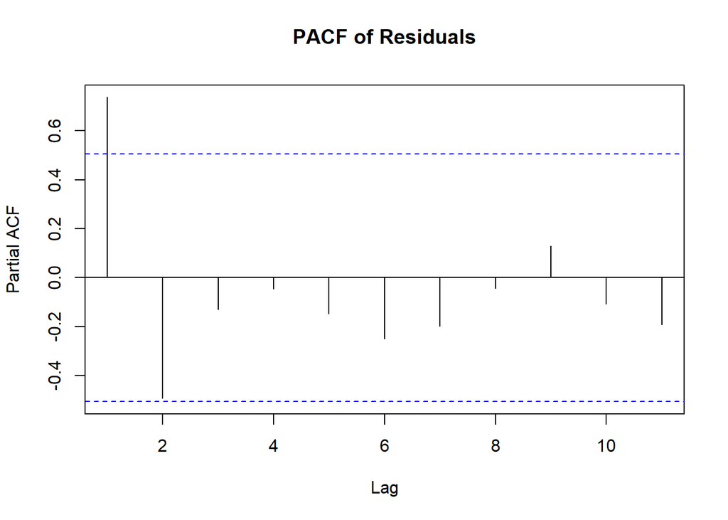

```r
# Plot PACF
pacf(res, main = "PACF of Residuals")
```

Selanjutnya, dilakukan penanganan autokorelasi pada model tersebut.

# Penanganan Autokorelasi

## Cochrane-orcutt

```r
library(orcutt)
cochrane.orcutt(model)
```

```
## Cochrane-orcutt estimation for first order autocorrelation
##
## Call:
## lm(formula = IPM ~ Tahun, data = df)
##
##  number of interaction: 54
##  rho 0.78572
##
## Durbin-Watson statistic
## (original):    0.38584 , p-value: 1.262e-06
## (transformed): 1.34437 , p-value: 4.891e-02
##
##  coefficients:
## (Intercept)       Tahun
## -915.696486    0.488701
```

Hasil dari penanganan autokorelasi dengan metode Cochrane Orcutt menghasilkan nilai p-value transformed sebesar 0,0489. Nilai tersebut masih berada di bawah batas signifikansi 0,05, sehingga autokorelasi belum sepenuhnya teratasi. Oleh karena itu, diperlukan penerapan metode lain untuk menangani permasalahan autokorelasi ini.

## Hildreth-Lu

```r
# Hildreth-Lu (does not require iterations)
rho = c(seq(0.1, 0.9, by = 0.1))

hildreth.lu <- function(rho, model){
  x <- model.matrix(model)[, -1]
  y <- model.response(model.frame(model))
  n <- length(y)
  t <- 2:n
  y <- y[t] - rho * y[t-1]
  x <- x[t] - rho * x[t-1]

  return(lm(y ~ x))
}
```

```r
# Ilustrasi penggunaan
fit <- lm(IPM ~ Tahun, data = df)
tab <- data.frame('rho' = rho,
                  'SSE' = sapply(rho, function(r) deviance(hildreth.lu(r, fit))))

round(tab, 4)
```

```
##   rho    SSE
## 1 0.1 0.7847
## 2 0.2 0.6534
## 3 0.3 0.5428
## 4 0.4 0.4528
## 5 0.5 0.3834
## 6 0.6 0.3347
## 7 0.7 0.3067
## 8 0.8 0.2993
## 9 0.9 0.3126
```

Hasil pencarian pada rentang rho 0,1 hingga 0,9 menunjukkan bahwa nilai SSE terkecil berada pada kisaran 0,7 hingga 0,8. Oleh karena itu, pencarian dilanjutkan dengan mempersempit nilai rho di sekitar rentang tersebut.

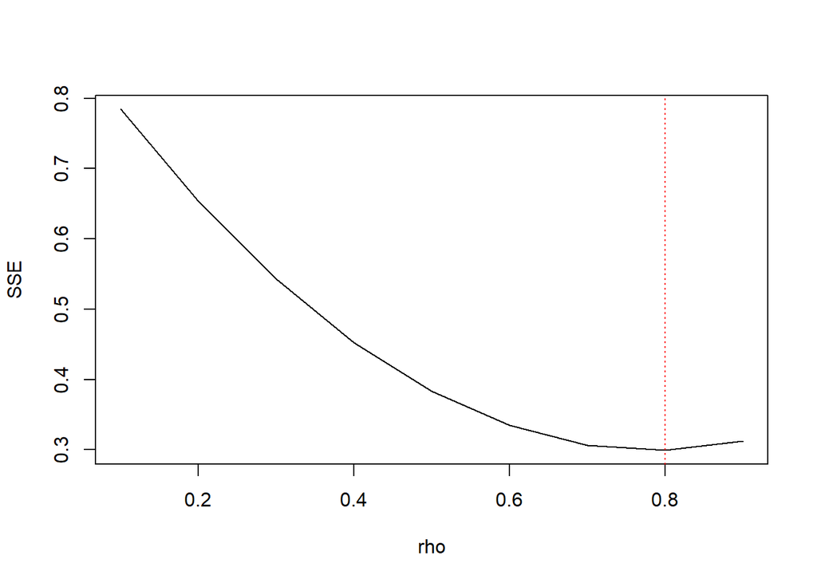

```r
plot(SSE ~ rho, data = tab, type = 'l')
abline(v = tab[tab$SSE == min(tab$SSE), "rho"], lty = 3, col = "red")
```

Hasil plot juga menunjukkan bahwa nilai rho dengan SSE minimum terdapat pada rentang 0.7 hingga 0.8, sehingga pencarian dilanjutkan.

```r
rho = c(seq(0.7, 0.9, by = 0.01))
tab <- data.frame('rho' = rho,
                  'SSE' = sapply(rho, function(r) deviance(hildreth.lu(r, fit))))

round(tab, 4)
```

```
##     rho    SSE
## 1  0.70 0.3067
## 2  0.71 0.3050
## 3  0.72 0.3035
## 4  0.73 0.3023
## 5  0.74 0.3012
## 6  0.75 0.3004
## 7  0.76 0.2998
## 8  0.77 0.2993
## 9  0.78 0.2991
## 10 0.79 0.2991
## 11 0.80 0.2993
## 12 0.81 0.2997
## 13 0.82 0.3003
## 14 0.83 0.3011
## 15 0.84 0.3021
## 16 0.85 0.3034
## 17 0.86 0.3048
## 18 0.87 0.3064
## 19 0.88 0.3083
## 20 0.89 0.3103
## 21 0.90 0.3126
```

```r
rho = c(seq(0.78, 0.79, by = 0.001))
tab <- data.frame('rho' = rho,
                  'SSE' = sapply(rho, function(r) deviance(hildreth.lu(r, fit))))

round(tab, 4)
```

```
##      rho    SSE
## 1  0.780 0.2991
## 2  0.781 0.2991
## 3  0.782 0.2991
## 4  0.783 0.2991
## 5  0.784 0.2991
## 6  0.785 0.2991
## 7  0.786 0.2991
## 8  0.787 0.2991
## 9  0.788 0.2991
## 10 0.789 0.2991
## 11 0.790 0.2991
```

Terlihat bahwa nilai SSE sama yaitu 0,2991. Oleh karena itu, nilai rho = 0,785 dipilih untuk dilakukan pengujian lebih lanjut.

```r
fit <- hildreth.lu(0.785, fit)
summary(fit)
```

```
##
## Call:
## lm(formula = y ~ x)
##
## Residuals:
##      Min       1Q   Median       3Q      Max
## -0.26579 -0.07519  0.01401  0.10572  0.19540
##
## Coefficients:
##               Estimate Std. Error t value Pr(>|t|)
## (Intercept) -196.99501   21.15512  -9.312 7.69e-07 ***
## x              0.48898    0.04868  10.044 3.41e-07 ***
## ---
## Signif. codes:  0 '***' 0.001 '**' 0.01 '*' 0.05 '.' 0.1 ' ' 1
##
## Residual standard error: 0.1579 on 12 degrees of freedom
## Multiple R-squared:  0.8937, Adjusted R-squared:  0.8848
## F-statistic: 100.9 on 1 and 12 DF,  p-value: 3.415e-07
```

```r
dwtest(fit)
```

```
##
##  Durbin-Watson test
##
## data:  fit
## DW = 1.3436, p-value = 0.04875
## alternative hypothesis: true autocorrelation is greater than 0
```

Hasil dari penanganan autokorelasi dengan metode Hildreth-Lu menghasilkan nilai p-value sebesar 0,04875. Nilai tersebut masih berada di bawah batas signifikansi 0,05, sehingga autokorelasi belum sepenuhnya teratasi. Oleh karena itu, diperlukan penerapan metode lain untuk menangani permasalahan autokorelasi ini.

# Kesimpulan

Metode Cochrane-Orcutt dan Hildreth-Lu belum sepenuhnya mampu mengatasi permasalahan autokorelasi pada data IPM Bengkulu periode 2010–2024. Oleh karena itu, diperlukan penerapan metode lain untuk menangani autokorelasi tersebut.